# Translation Factors in Zebrafish Maternal and Somatic Ribosomes

G da Silva Pescador

May 06, 2025

# 1 Packages

```r
library(here)
library(tidyverse)
library(data.table)
library(readxl)
library(ggplot2)
library(ggpubr)
library(ggforce)
library(ggborderline)
library(ggrepel)
library(UpSetR)
library(eulerr)
library(cowplot)
library(rstatix)
library(VennDiagram)
library(OrgMassSpecR)
library(org.Dr.eg.db)
library(KEGGREST)
library(clusterProfiler)

#remotes::install_github('yihui/xfun')
# embed_file() requires a few more packages
xfun::pkg_load2(c('htmltools', 'mime'))
```

# 2 Functions

```r
# Get gene name from KEGG pathways

# Create a function that gives me gene names based on the KEGG IDs
getGeneNames_KEGG <- function(pathwayID){

  # pathwayID should be either number or with organism specified
  # e.g., dre03010 where "dre" refers to Danio rerio
  pathway_genes <- keggGet(pathwayID)

  # Extract gene information for the pathway
  genes_info <- character()
  for(i in 1:length(pathway_genes)){
    temp <- pathway_genes[[i]]$GENE # Get gene annotation from pathway
    temp <- temp[seq(2, length(temp), by = 2)] # get only gene names
    temp <- sapply(strsplit(temp, " "), `[`, 1) # Keep only the first word, which is the gene name
    temp <- sub("[^a-zA-Z0-9:]", "", temp) # Get rid of ; from the name
    genes_info <- append(genes_info, temp)
  }
  print(genes_info)
}

# Make rownames of upsetR to be your list of arguments
# This was created by: https://github.com/docmanny
fromList <- function (input) {
  # Make rownames of upsetR to be your list of arguments
  # created by: https://github.com/docmanny
  # Same as original fromList()...
  elements <- unique(unlist(input))
  data <- unlist(lapply(input, function(x) {
      x <- as.vector(match(elements, x))
      }))
  data[is.na(data)] <- as.integer(0)
  data[data != 0] <- as.integer(1)
  data <- data.frame(matrix(data, ncol = length(input), byrow = F))
  data <- data[which(rowSums(data) != 0), ]
  names(data) <- names(input)
  # ... Except now it conserves your original value names!
  row.names(data) <- elements
  return(data)
}

# Wrapper around Digest from OrgMassSpecR to digest several sequences from a dataframe
DigestBatch <- function(df, enz, miss){
  # Batch a dataframe of protein sequences and rbind the figestion results
  # df is a dataframe with aminoacid sequence in a column named Sequence
  # df also needs first column to have the protein ID
  # enz specifies enzyme from function Digest
  # miss specifies how many missing cleavages from function Digest
  output <- data.frame()
  for(i in 1:nrow(df)){
  temp <- Digest(df$Sequence[i],
                 enzyme = enz,
                 missed = miss)
  temp$Protein <- as.character(df[i,1])
  temp$Name <- as.character(df[i,5])
  output <- rbind(output, temp)
  }
return(output)
}

# function to transform dataframe sequences into FASTA format
fastaTransform <- function(df, organism, outputpath){
  # Takes a dataframe downloaded from UNIPROT that has at least:
  # Entry - with uniprot ID
  # Sequence - with aminoacid sequence from UNIPROT
  # Then transforms all sequences into FASTA format

df2 <- data.frame(id = c(df$Entry),
                 Organism = organism,
                 seq = c(df$Sequence))
df2$fasta_name <- paste0(df2$id, "_", df2$Organism)

zf_fasta <- unlist(
  mapply(function(fasta_name, seq) {
    c(paste0(">", fasta_name), seq)
  }, df2$fasta_name, df2$seq, SIMPLIFY = FALSE)
)
writeLines(zf_fasta, paste0(outputpath, organism, "_output.fasta"))

}
```

# 3 Introduction

This is a collaboration between me and Ariel (Bazzini Lab), and Leo and Kamena (Kostova Lab).

The goal of this analysis is to use public zebrafish proteomics datasets to compare presence or absence of translation factors when only maternal or only somatic ribosomes are present in the life of the embryo.

A list of all datasets that passed quality check is included in “/ProcessingFiles/Datasets_metadata.xlsx”.

# 4 Loading and annotating all datasets

```r
# Define the path to look for files
DirPath <- here("SearchResults")

# Define the file extension to look for
FileExtLFQ <- "combined_protein.tsv$" # combined_protein.tsv for label-free
FileExtLabel <- "abundance_gene_MD.tsv$" # abundance_gene_MD.tsv for isobaric labeling

# List all files with the specified ending notation in subdirectories for LFQ data
FileListLFQ <- list.files(path = DirPath,
                              pattern = FileExtLFQ,
                              recursive = TRUE,
                              full.names = TRUE)

data <- list()
# Loop through each file for LFQ
for (file_path in FileListLFQ) {
  # Extract the dataset name
  dataset_name <- str_extract(file_path, "PXD\\d+")

  # Create an object name based on the subfolder name
  object_name <- paste0(dataset_name, "_LFQdata")

  # Read the file into the created object name
  # assign(object_name, fread(file_path), envir = .GlobalEnv) # assign doesn't work well with knitting so will assign things to a list instead
  data[[object_name]] <- fread(file_path)

  # Print a message to confirm that the file has been read
  cat("Loaded", file_path, "into object", object_name, "\n")
}

# List all files with the specified ending notation in subdirectories for LFQ data
FileListLabel <- list.files(path = DirPath,
                              pattern = FileExtLabel,
                              recursive = TRUE,
                              full.names = TRUE)

# Loop through each file for isobaric label
for (file_path in FileListLabel) {
  # Extract the dataset name
  dataset_name <- str_extract(file_path, "PXD\\d+")

  # Create an object name based on the subfolder name
  object_name <- paste0(dataset_name, "_Isobaricdata")

  # Read the file into the created object name
  # assign(object_name, fread(file_path), envir = .GlobalEnv)
  data[[object_name]] <- fread(file_path)

  # Print a message to confirm that the file has been read
  cat("Loaded", file_path, "into object", object_name, "\n")
}
```

Since we are interested in different time points, I will annotate the column names to make it easier to filter based on stages.

*Note:* Next time should probably set this in the FragPipe workflow/manifest instead.

```r
# Start with LFQ objects

#PXD002124_LFQdata is ok
names(data[["PXD005129_LFQdata"]]) <- str_replace(names(data[["PXD005129_LFQdata"]]), " Intensity", "_Oocyte_Intensity")
#PXD005137_LFQdata is ok
names(data[["PXD009612_LFQdata"]]) <- str_replace(names(data[["PXD009612_LFQdata"]]), " Intensity", "_6dpf_Intensity")
#PXD010922_LFQdata is ok
#PXD013835_LFQdata is ok
#PXD016714_LFQdata is ok
#PXD017419_LFQdata is ok
#PXD017896_LFQdata is ok
names(data[["PXD021302_LFQdata"]]) <- str_replace(names(data[["PXD021302_LFQdata"]]), " Intensity", "_Oocyte_Intensity")
names(data[["PXD021670_LFQdata"]]) <- str_replace(names(data[["PXD021670_LFQdata"]]), " Intensity", "_5dpf_Intensity")
names(data[["PXD022578_LFQdata"]]) <- str_replace(names(data[["PXD022578_LFQdata"]]), " Intensity", "_7-10dpf_Intensity")
names(data[["PXD025850_LFQdata"]]) <- str_replace(names(data[["PXD025850_LFQdata"]]), " Intensity", "_6dpf_Intensity")
#PXD039348_LFQdata is ok
names(data[["PXD042791_LFQdata"]]) <- str_replace(names(data[["PXD042791_LFQdata"]]), "E Intensity", "Oocyte_Intensity")
names(data[["PXD042791_LFQdata"]]) <- str_replace(names(data[["PXD042791_LFQdata"]]), "L Intensity", "Liver_Intensity")
names(data[["PXD043679_LFQdata"]]) <- str_replace(names(data[["PXD043679_LFQdata"]]), "72h", "3dpf_Intensity")
names(data[["PXD043679_LFQdata"]]) <- str_replace(names(data[["PXD043679_LFQdata"]]), "120h", "5dpf_Intensity")
```

# 5 Quality Check for datasets

*Note:* Since we are interested only in presence/absence I did not perform any sort of normalization for the datasets.

```r
PXDObjects <- names(data)[str_detect(names(data), "LFQ")]

# First step is clean the data from contaminants, since we are only interested in the zebrafish proteins identified.

# This for loop will filter out contaminant proteins identified from the dataframes and assign them to a new object "_Cleaned"
data_cleaned <- list()
for(i in PXDObjects){
  # Create an object name based on the subfolder name
  object_name <- paste0(i, "_Cleaned")

  # Assign the filtered dataframe to a new object
  df <- data[[i]] %>%
    filter(!str_detect(Protein, "contam"))

  # Assign the filtered dataframe to a new object with the specified name
  #assign(object_name, df, envir = .GlobalEnv)
  data_cleaned[[object_name]] <- df
}

# Now we can start checking how the expression without normalization is in each experiment by plotting boxplots.

PXDObjectsCl <- names(data_cleaned)

temp <- list()
for(i in PXDObjectsCl){

  # Assign the filtered dataframe to a new object
  df <- data_cleaned[[i]] %>%
    dplyr::select(`Protein`, `Protein ID`, `Gene`, `Description`, contains("Spectral Count"):last_col(1), -contains("MaxLFQ"), -contains("Spectral Count")) %>%
    rename_with(~ str_replace(., " Intensity", ""), contains("Intensity")) %>%
    reshape2::melt(id.vars = c("Protein", "Protein ID", "Gene", "Description"))

  # Plot boxplots for each dataset to look for normalization
  plots <- df %>%
    ggplot(aes(x=variable, y=log2(value))) +
    geom_boxplot() +
    theme_classic() +
    theme(axis.text.x = element_text(angle = 45, hjust = 1)) +
    ggtitle(i)

  ggsave(plot = plots, paste0(here("Plots/"), i, "_boxplot", ".pdf"), width = 6, height = 5)

  temp[[i]] <- plots
}

# Then saving all filtered tables
for(i in PXDObjectsCl){
  data_cleaned[[i]] %>%
    write_csv(paste0(here("OutputTables/"), i, ".csv"))
}
```

*Note:* Same here for labelled datasets, no normalization was performed.

```r
PXDObjects <- names(data)[str_detect(names(data), "Isobaric")]


for(i in PXDObjects){

  # Assign the filtered dataframe to a new object
  df <- data[[i]] %>%
    setNames(make.unique(names(.))) %>%
    dplyr::select(`Index`, `ProteinID`, ReferenceIntensity:last_col()) %>%
    reshape2::melt(id.vars = c("Index", "ProteinID"))

  # Plot boxplots for each dataset to look for normalization
  plots <- df %>%
    filter(!variable == "ReferenceIntensity") %>%
    ggplot(aes(x=variable, y=log2(value))) +
    geom_boxplot() +
    theme_classic() +
    theme(axis.text.x = element_text(angle = 45, hjust = 1)) +
    ggtitle(i)

  ggsave(plot = plots, paste0(here("Plots/"), i, "_boxplot", ".pdf"), width = 6, height = 5)

  temp[[i]] <- plots
}

# Then saving all filtered tables
for(i in PXDObjects){
  data[[i]] %>%
    write_csv(paste0(here("OutputTables/"), i, ".csv"))
}
```

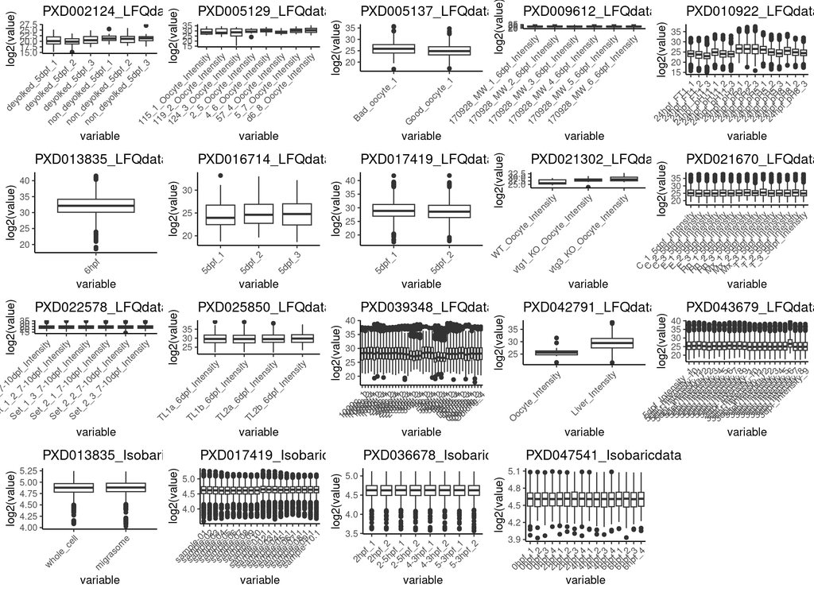

```r
cowplot::plot_grid(plotlist = temp)
```

# 6 Compiling protein IDs per stage

First, I will filter any protein that is not quantified in any of the samples, as they are usually low confident protein identifications. Then, I will create a combined long format data frame for easier manipulation of the IDs.

## 6.1 LFQ Tables

```r
PXDObjects <- names(data_cleaned)[str_detect(names(data_cleaned), "LFQdata_Cleaned")]

# First, filtering all proteins that have no quantification, and were only found as peptide identifications.
long_df <- data.frame()
for(i in PXDObjects){
   # Create an object name
  object_name <- "Combined_Filtered"

  # Assign the filtered dataframe to a new object
  df <- data_cleaned[[i]] %>%
    dplyr::select(colnames(.)[1:13], contains("Intensity"), -contains("MaxLFQ"), last_col()) %>%
    relocate(., `Indistinguishable Proteins`, .after = `Combined Unique Spectral Count`) %>%
    reshape2::melt(id.vars = c(colnames(.)[1:14])) %>%
    filter(!value == 0) %>%
    mutate(Dataset = str_split(i, "_")[[1]][1])

  # Rbind all melted tables and filter for values == 0
  long_df <- rbind(long_df, df)

}

Combined_Filtered <- long_df

# Now annotating the stages
# unique(Combined_Filtered$variable)

# very manual way of doing it, I should automate it in the future
Combined_Filtered <- Combined_Filtered %>%
  filter(!str_detect(variable, "Liver|liver")) %>%
  mutate(Stage = case_when(
    str_detect(.$variable, "oocyte|Oocyte") ~ "Oocyte",
    str_detect(.$variable, "0hpf") ~ "s0hpf",
    str_detect(.$variable, "4c") ~ "s1hpf",
    str_detect(.$variable, "32c") ~ "s1-75hpf",
    str_detect(.$variable, "2hpf") ~ "s2hpf",
    str_detect(.$variable, "256c") ~ "s2-5hpf",
    str_detect(.$variable, "512c") ~ "s2-75hpf",
    str_detect(.$variable, "1000c") ~ "s3hpf",
    str_detect(.$variable, "oblong|Oblong") ~ "s3-66hpf",
    str_detect(.$variable, "^4hpf") ~ "s4hpf",
    str_detect(.$variable, "dome|Dome") ~ "s4-33hpf",
    str_detect(.$variable, "6hpf") ~ "s6hpf",
    str_detect(.$variable, "bud|Bud") ~ "s10hpf",
    str_detect(.$variable, "16hpf") ~ "s16hpf",
    str_detect(.$variable, "24hpf") ~ "s24hpf",
    str_detect(.$variable, "28hpf") ~ "s28hpf",
    str_detect(.$variable, "3dpf") ~ "s3dpf",
    str_detect(.$variable, "5dpf") ~ "s5dpf",
    str_detect(.$variable, "6dpf") ~ "s6dpf",
    str_detect(.$variable, "10dpf") ~ "s10dpf",
  ))

write_csv(Combined_Filtered, paste0(here("OutputTables/"), "LFQ_combined_filtered.csv"))

knitr::kable(head(Combined_Filtered))
```

| Protein | Protein ID | Entry Name | Gene | Protein Length | Organism | Protein Existence | Description | Protein Probability | Top Peptide Probability | Combined Total Peptides | Combined Spectral Count | Combined Unique Spectral Count | Indistinguishable Proteins | variable | value | Dataset | Stage |
| --- | --- | --- | --- | --- | --- | --- | --- | --- | --- | --- | --- | --- | --- | --- | --- | --- | --- |
| sp\|F1QGH7\|CTNB1_DANRE | F1QGH7 | CTNB1_DANRE | ctnnb1 | 780 | Danio rerio | 1:Experimental evidence at protein level | Catenin beta-1 | 0.3176 | 0.8650 | 1 | 2 | 2 |  | deyolked_5dpf_1 Intensity | 263118.75 | PXD002124 | s5dpf |
| sp\|F1R4U0\|TXTPB_DANRE | F1R4U0 | TXTPB_DANRE | slc25a1b | 317 | Danio rerio | 3:Protein inferred from homology | Tricarboxylate transport protein B, mitochondrial | 0.8401 | 0.9864 | 1 | 1 | 1 |  | deyolked_5dpf_1 Intensity | 37699.34 | PXD002124 | s5dpf |
| sp\|O57521\|HS90B_DANRE | O57521 | HS90B_DANRE | hsp90ab1 | 725 | Danio rerio | 1:Experimental evidence at protein level | Heat shock protein HSP 90-beta | 1.0000 | 0.9988 | 3 | 17 | 4 |  | deyolked_5dpf_1 Intensity | 913438.44 | PXD002124 | s5dpf |
| sp\|O73872\|SODC_DANRE | O73872 | SODC_DANRE | sod1 | 154 | Danio rerio | 2:Experimental evidence at transcript level | Superoxide dismutase [Cu-Zn] | 1.0000 | 0.9967 | 1 | 10 | 10 |  | deyolked_5dpf_1 Intensity | 2262562.50 | PXD002124 | s5dpf |
| sp\|O93409\|MLRSA_DANRE | O93409 | MLRSA_DANRE | mylpfa | 169 | Danio rerio | 1:Experimental evidence at protein level | Myosin regulatory light chain 2, skeletal muscle isoform A | 1.0000 | 0.9989 | 9 | 29 | 1 |  | deyolked_5dpf_1 Intensity | 258607.80 | PXD002124 | s5dpf |
| sp\|P13104\|TPM1_DANRE | P13104 | TPM1_DANRE | tpma | 284 | Danio rerio | 2:Experimental evidence at transcript level | Tropomyosin alpha-1 chain | 1.0000 | 0.9970 | 7 | 23 | 23 |  | deyolked_5dpf_1 Intensity | 4794508.00 | PXD002124 | s5dpf |

## 6.2 Isobaric Label Tables

Same for Isobaric tables.

```r
PXDObjects <- names(data)[str_detect(names(data), "Isobaric")]

# First, filtering all proteins that have no quantification, and were only found as peptide identifications.
long_df <- data.frame()
for(i in PXDObjects){
   # Create an object name based on the subfolder name
  object_name <- "Combined_Filtered_Isobaric"

  # Assign the filtered dataframe to a new object
  df <- data[[i]] %>%
    #dplyr::select(colnames(.)[1:5], contains("Intensity"), -contains("MaxLFQ"), last_col()) %>%
    #relocate(., `Indistinguishable Proteins`, .after = `Combined Unique Spectral Count`) %>%
    reshape2::melt(id.vars = c(colnames(.)[1:5])) %>%
    filter(!value == 0) %>%
    mutate(Dataset = str_split(i, "_")[[1]][1])

  # Rbind all melted tables and filter for values == 0
  long_df <- rbind(long_df, df)

}

Combined_Filtered_Isobaric <- long_df
# Now annotating the stages
# unique(Combined_Filtered_Isobaric$variable)

Combined_Filtered_Isobaric <- Combined_Filtered_Isobaric %>%
  mutate(Stage = case_when(
    str_detect(.$variable, "whole_cell") ~ "s6hpf",
    str_detect(.$variable, "migrasome") ~ "s6hpf_migrasome",
    str_detect(.$variable, "sample-01|sample-02|sample-03|sample-04|sample-05|sample-06|sample-07|sample-08|sample-09|sample-10") & str_detect(.$Dataset, "PXD013835") ~ "s6hpf_migrasome",
    str_detect(.$variable, "sample-01|sample-02|sample-03|sample-04|sample-05|sample-06|sample-07|sample-08|sample-09|sample-10") & str_detect(.$Dataset, "PXD017419") ~ "s5dpf",
    str_detect(.$variable, "0hpf") ~ "s0hpf",
    str_detect(.$variable, "4c") ~ "s1hpf",
    str_detect(.$variable, "32c") ~ "s1-75hpf",
    str_detect(.$variable, "2hpf") ~ "s2hpf",
    str_detect(.$variable, "256c") ~ "s2-5hpf",
    str_detect(.$variable, "512c") ~ "s2-75hpf",
    str_detect(.$variable, "1000c") ~ "s3hpf",
    str_detect(.$variable, "3hpf") ~ "s3hpf",
    str_detect(.$variable, "oblong|Oblong") ~ "s3-66hpf",
    str_detect(.$variable, "^4hpf") ~ "s4hpf",
    str_detect(.$variable, "dome|Dome") ~ "s4-33hpf",
    str_detect(.$variable, "5hpf") ~ "s5hpf",
    str_detect(.$variable, "6hpf") ~ "s6hpf",
    str_detect(.$variable, "bud|Bud") ~ "s10hpf",
    str_detect(.$variable, "16hpf") ~ "s16hpf",
    str_detect(.$variable, "24hpf") ~ "s24hpf",
    str_detect(.$variable, "28hpf") ~ "s28hpf",
    str_detect(.$variable, "3dpf") ~ "s3dpf",
    str_detect(.$variable, "5dpf") ~ "s5dpf",
    str_detect(.$variable, "6dpf") ~ "s6dpf",
    str_detect(.$variable, "10dpf") ~ "s10dpf",
  ))

write_csv(Combined_Filtered_Isobaric,
          paste0(here("OutputTables/"), "Isobaric_combined_filtered.csv"))

knitr::kable(head(Combined_Filtered_Isobaric))
```

| Index | NumberPSM | ProteinID | MaxPepProb | ReferenceIntensity | variable | value | Dataset | Stage |
| --- | --- | --- | --- | --- | --- | --- | --- | --- |
| Bag6 | 10 | A3KPW9 | 0.9985 | 30.64722 | whole_cell | 30.87447 | PXD013835 | s6hpf |
| Ctnna2 | 1 | B7ZC77 | 0.9997 | 24.13711 | whole_cell | 23.69424 | PXD013835 | s6hpf |
| Fam174b | 1 | Q1LVN1 | 0.9942 | 17.56996 | whole_cell | 17.36415 | PXD013835 | s6hpf |
| LYRM7 | 21 | A5PLG0 | 1.0000 | 32.13971 | whole_cell | 31.48853 | PXD013835 | s6hpf |
| Maco1a | 3 | Q2TLY2 | 0.9893 | 25.62152 | whole_cell | 25.36682 | PXD013835 | s6hpf |
| Ninl | 7 | G9G127 | 0.9987 | 28.45500 | whole_cell | 28.32832 | PXD013835 | s6hpf |

## 6.3 Combining both long data frames into one

To be able to plot in a more visual way, I decided to combine stages based on the plot Leo sent me on Maternal/Somatic K-mers. That way I named each group type as:

- Maternal: Between 0hpf to 10hpf (>90% maternal)
- Maternal-Somatic: Between 16hpf to 28hpf (< 50% somatic)
- Somatic: Any other time point with > 50% somatic contribution

```r
# First make them the same columns
LFQ <- Combined_Filtered[,c(2,4,15,16,17,18)]
LFQ$value <- log2(LFQ$value)
Isobaric <- Combined_Filtered_Isobaric[,c(1,3,6,7,8,9)]
Isobaric$Index <- tolower(Isobaric$Index)
Isobaric <- relocate(Isobaric, ProteinID, .before = Index)
colnames(LFQ) <- c("Accession", "Name", "variable", "value", "Dataset", "Stage")
colnames(Isobaric) <- c("Accession", "Name", "variable", "value", "Dataset", "Stage")

Combined <- rbind(LFQ, Isobaric)

# Now annotate if they are Maternal, MaternalSomatic or Somatic stages based on the annotated stages
Combined$Type <- ifelse(Combined$Stage %in% c("Oocyte", "oocyte", "s0hpf", "s1hpf", "s1-75hpf", "s2hpf", "s2-5hpf", "s2-75hpf",
              "s3hpf", "s3-66hpf", "s4hpf", "s4-33hpf", "s5hpf", "s6hpf", "s6hpf_migrasome",
              "s10hpf"),
              "Maternal",
              ifelse(Combined$Stage %in% c("s16hpf", "s24hpf", "s28hpf"),
                     "MaternalSomatic",
                     "Somatic"))

write_csv(Combined, paste0(here("OutputTables/"), "Combined_both_longformat.csv"))

knitr::kable(head(Combined))
```

| Accession | Name | variable | value | Dataset | Stage | Type |
| --- | --- | --- | --- | --- | --- | --- |
| F1QGH7 | ctnnb1 | deyolked_5dpf_1 Intensity | 18.00535 | PXD002124 | s5dpf | Somatic |
| F1R4U0 | slc25a1b | deyolked_5dpf_1 Intensity | 15.20225 | PXD002124 | s5dpf | Somatic |
| O57521 | hsp90ab1 | deyolked_5dpf_1 Intensity | 19.80095 | PXD002124 | s5dpf | Somatic |
| O73872 | sod1 | deyolked_5dpf_1 Intensity | 21.10953 | PXD002124 | s5dpf | Somatic |
| O93409 | mylpfa | deyolked_5dpf_1 Intensity | 17.98041 | PXD002124 | s5dpf | Somatic |
| P13104 | tpma | deyolked_5dpf_1 Intensity | 22.19295 | PXD002124 | s5dpf | Somatic |

# 7 Checking how many unique proteins we identified per dataset and per stage

## 7.1 Per dataset

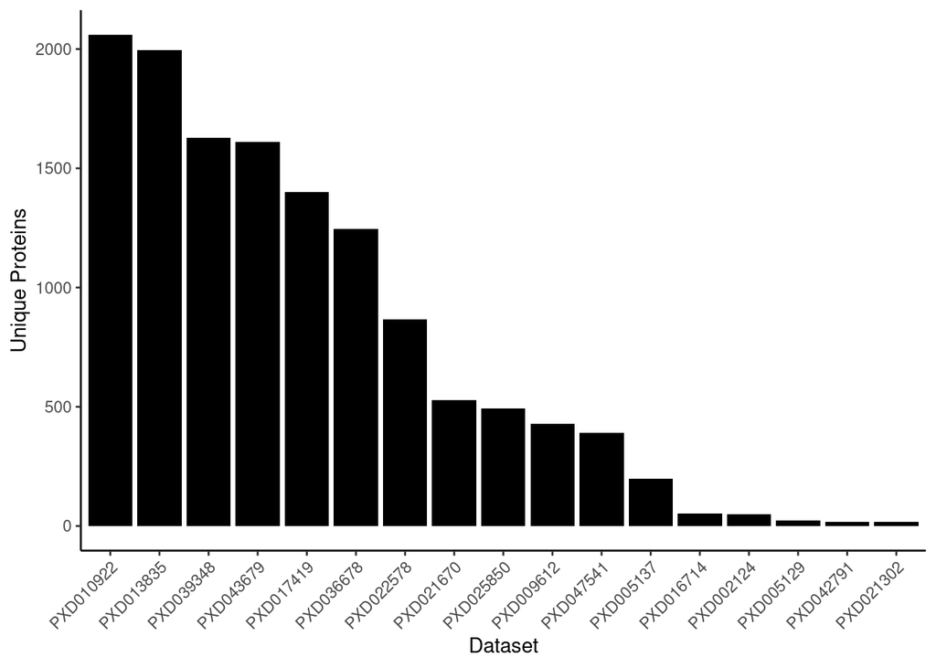

```r
# How many proteins per dataset
Combined %>%
  group_by(Dataset) %>%
  summarize(Counts = length(unique(Accession))) %>%
  mutate(Dataset = reorder(Dataset, -Counts)) %>%
  ggplot(aes(x=Dataset, y=Counts)) +
  geom_bar(stat = "identity", fill = "black") +
  theme_classic() +
  theme(axis.text.x = element_text(angle = 45, hjust = 1)) +
  ylab("Unique Proteins")
```

```r
ggsave(paste0(here("Plots/"), "bar_uniqueProteins.pdf"), width = 4, height = 4)
```

## 7.2 Per developmental stage

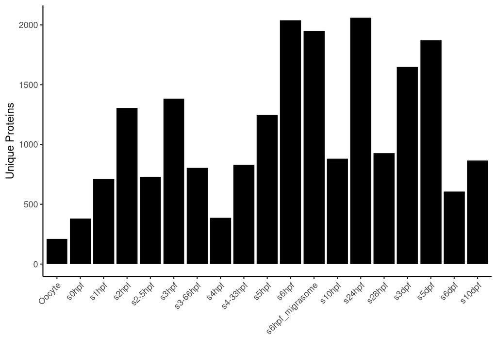

```r
# How many proteins per stage
ordering <- c("Oocyte", "s0hpf", "s1hpf", "s1-75hpf", "s2hpf", "s2-5hpf", "s2-75hpf",
              "s3hpf", "s3-66hpf", "s4hpf", "s4-33hpf", "s5hpf", "s6hpf", "s6hpf_migrasome",
              "s10hpf", "s16hpf", "s24hpf", "s28hpf", "s3dpf",  "s5dpf", "s6dpf", "s10dpf")

Combined %>%
  group_by(Stage) %>%
  summarize(Counts = length(unique(Accession))) %>%
  mutate(Stage = factor(Stage, ordering)) %>%
  ggplot(aes(x=Stage, y=Counts)) +
  geom_bar(stat = "identity", fill = "black") +
  theme_classic() +
  theme(axis.text.x = element_text(angle = 45, hjust = 1)) +
  ylab("Unique Proteins") +
  xlab("")
```

```r
ggsave(paste0(here("Plots/"), "bar_uniqueProteins_perstage.pdf"), width = 4, height = 2.5)
```

# 8 Getting lists of proteins of interest

The main interest is differences in translation factors and Piwi pathways between different stages, so I will:

1. Get a list of which are these genes for each pathway.
2. Check each dataset for presence and compile presence for each stage.
3. Plot venn diagrams (eulerr) for presence in each developmental stage.
4. Generate a table with the shared proteins and the non-shared ones for Leo.

## 8.1 KEGG Lists

KEGG lists problem is that it only gives gene names, and not an ID or accession ID.

This did not give all terms that I was looking for, so I will try different method.

## 8.2 Gene Ontology (GO) Lists

Using clusterprofiler for GO was not great, so I will stick to downloading from Uniprot directly moving forward.

## 8.3 Using UNIPROT

No package worked properly, so I resorted to searching uniprot website for the GO Terms in zebrafish and downloading the IDs.

Translation GOTerms:

- GO:0006412

piRNA GOTerms:

- GO:0140541
- GO:0034587

```r
# For translation-related proteins
translation_UP <- rbind(fread(here("OutputTables", "uniprotkb_go_0006412_AND_taxonomy_id_79_2024_11_07.tsv")),                        fread(here("OutputTables", "uniprotkb_taxonomy_id_7955_AND_go_00081_2024_11_08.tsv")))

piRNA_UP <- fread(here("OutputTables", "uniprotkb_go_0140541_OR_go_0034587_OR_g_2024_11_07.tsv"))
```

# 9 Translation Protein IDs

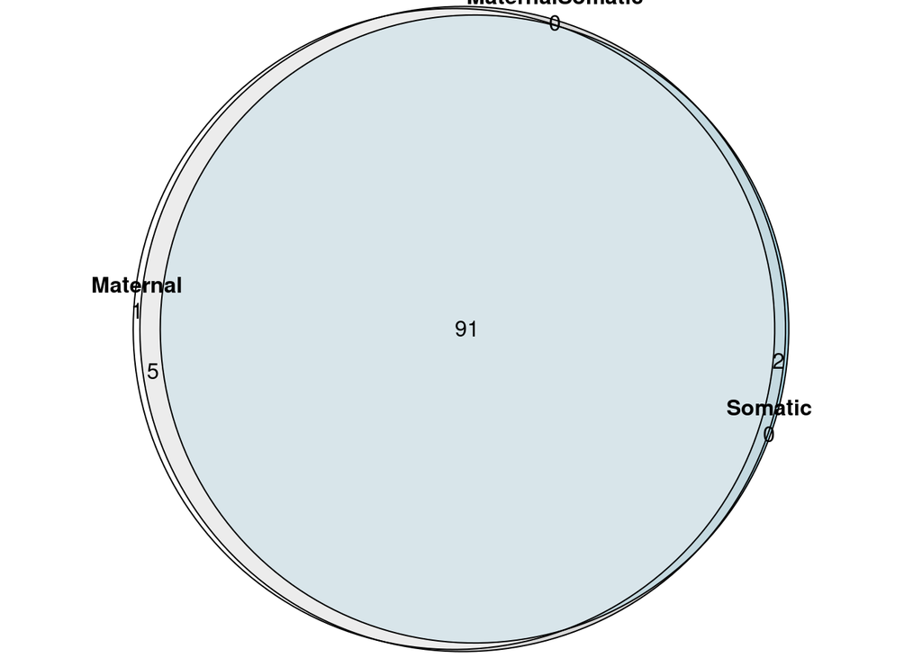

```r
# First filter the long df
translation_related <- filter(Combined, Accession %in% translation_UP$Entry)

# Now keep only the unique Protein IDs
translation_related <- translation_related %>%
  group_by(Stage) %>%
  summarize(Accession = unique(Accession))

translation_related <- merge(translation_related, Combined[,c(1,2,7)], by="Accession") %>%
  .[!duplicated(.),]

# Now create a list of protein IDs for each stage
translation_related_type <- translation_related %>%
  group_by(Type) %>%
  summarize(Accession = unique(Accession))

stage_list_translation <- split(translation_related_type$Accession, translation_related_type$Type)

# # Set order
# ordering <- c("s0hpf", "s1hpf", "s1-75hpf", "s2hpf", "s2-5hpf", "s2-75hpf",
#               "s3hpf", "s3-66hpf", "s4hpf", "s4-33hpf", "s5hpf", "s6hpf", "s6hpf_migrasome",
#               "s10hpf", "s16hpf", "s24hpf", "s28hpf", "s3dpf",  "s5dpf", "s6dpf", "s10dpf")

# Euler plot
euler_trans <- euler(stage_list_translation)

p1 <- plot(euler_trans,
     quantities = TRUE)

p1
```

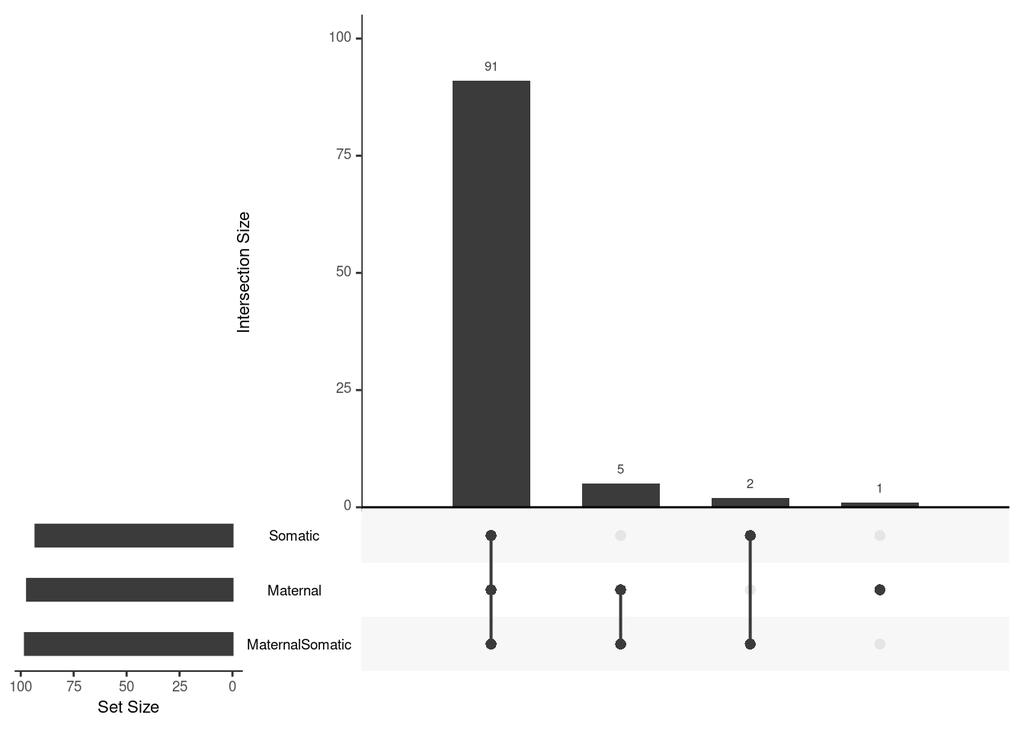

```r
pdf(paste0(here("Plots/"), "venn_translation_proteins.pdf"), width = 4, height = 4)
p1
dev.off()

# UpsetR plot
p1 <- upset(fromList(stage_list_translation),
      order.by = "freq",
      nsets = 20)

pdf(paste0(here("Plots/"),"upsetR_translation_proteins.pdf"), width = 4, height = 4)
p1
dev.off()

p1
```

## 9.1 Getting which proteins are from which group

```r
# Getting each groups values
df <- p1$New_data
# Find unique intersections for each row
df$Intersection <- apply(df[, c("Maternal", "MaternalSomatic", "Somatic")], 1, function(row) {
  # Get the names of the columns with value 1
  intersecting_groups <- names(row)[row == 1]
  # Concatenate the names to form the intersection label
  paste(intersecting_groups, collapse = "_")
})

df$Acession <- rownames(df)
# Make this more readable with gene names
for(i in df$Intersection){
  temp <- df %>%
  filter(Intersection == i) %>%
  pivot_wider(id_cols = Acession,
              names_from = Intersection,
              values_from = Intersection)

  colnames(temp) <- c(i, "type")
  temp <- merge(temp, unique(Combined[,c(1,2)]),
        by.x=i, by.y="Accession")

  write_csv(temp, paste0(here("OutputTables/"), "translation_", i, ".csv"))
}

knitr::kable(head(temp))
```

| MaternalSomatic_Somatic | type | Name |
| --- | --- | --- |
| Q1LUA8 | MaternalSomatic_Somatic | eif3eb |
| Q7SXN4 | MaternalSomatic_Somatic | cpeb4 |

# 10 piRNA Protein IDs

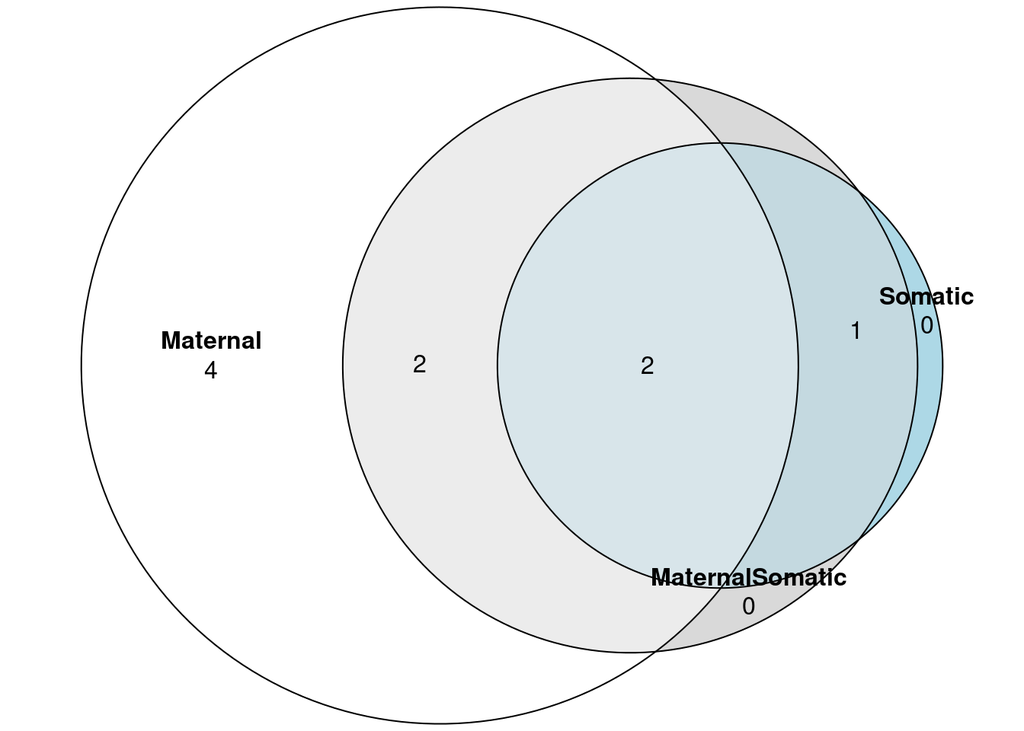

```r
# First filter the long df
piRNA_related <- filter(Combined, Accession %in% piRNA_UP$Entry)

# Now keep only the unique Protein IDs
piRNA_related <- piRNA_related %>%
  group_by(Stage) %>%
  summarize(Accession = unique(Accession))

piRNA_related <- merge(piRNA_related, Combined[,c(1,2,7)], by="Accession") %>%
  .[!duplicated(.),]

# Now create a list of protein IDs for each stage
piRNA_related_type <- piRNA_related %>%
  group_by(Type) %>%
  summarize(Accession = unique(Accession))

stage_list_piRNA <- split(piRNA_related_type$Accession, piRNA_related_type$Type)

euler_piRNA <- euler(stage_list_piRNA)


p2 <- plot(euler_piRNA,
     quantities = TRUE)

p2
```

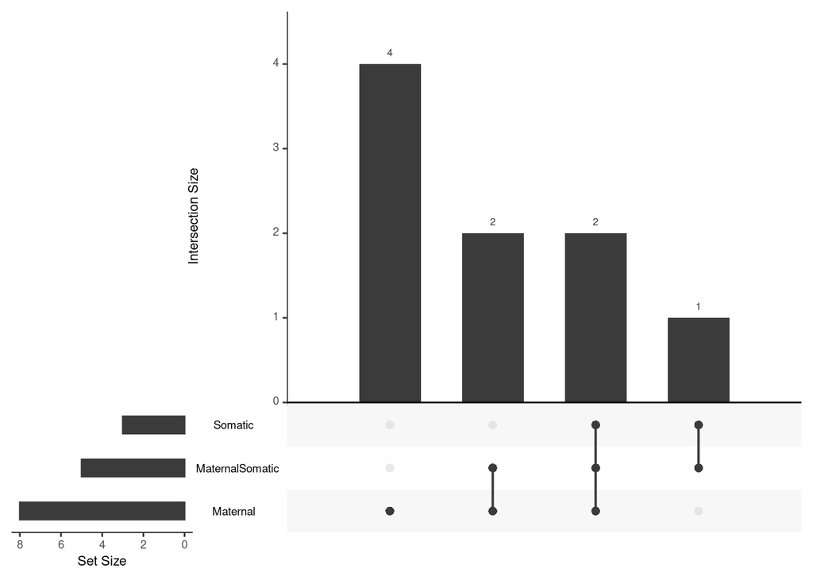

```r
pdf(paste0(here("Plots/"), "venn_piRNA_proteins.pdf"), width = 4, height = 4)
p2
dev.off()

p2 <- upset(fromList(stage_list_piRNA),
      order.by = "freq",
      nsets = 20)

pdf(paste0(here("Plots/"), "upsetR_piRNA_proteins.pdf"), width = 4, height = 4)
p2
dev.off()

p2
```

## 10.1 Getting groups

```r
# Getting each groups values
df <- p2$New_data
# Find unique intersections for each row
df$Intersection <- apply(df[, c("Maternal", "MaternalSomatic", "Somatic")], 1, function(row) {
  # Get the names of the columns with value 1
  intersecting_groups <- names(row)[row == 1]
  # Concatenate the names to form the intersection label
  paste(intersecting_groups, collapse = "_")
})

df$Acession <- rownames(df)
# Make this more readable with gene names
for(i in df$Intersection){
  temp <- df %>%
  filter(Intersection == i) %>%
  pivot_wider(id_cols = Acession,
              names_from = Intersection,
              values_from = Intersection)

  colnames(temp) <- c(i, "type")
  temp <- merge(temp, unique(Combined[,c(1,2)]),
        by.x=i, by.y="Accession")

  write_csv(temp, paste0(here("OutputTables/"), "piRNA_", i, ".csv"))
}

knitr::kable(head(temp))
```

| MaternalSomatic_Somatic | type | Name |
| --- | --- | --- |
| E7FDW8 | MaternalSomatic_Somatic | tdrd7b |

# 11 Most translated genes between 0-6hpf

Here, we will get a list of the top 10 translated genes from our [proteomics dataset](https://doi.org/10.1016/j.celrep.2024.114769) for Leo to use.

```r
# Load the tables for each timepoint
a <- read_excel(here("OutputTables", "daSilvaPescador_TableS1.xlsx"),
                skip = 1,
                sheet = 2)
a$`2h_adj.P.Val` <- as.numeric(a$`2h_adj.P.Val`)
a$`2h_adj.P.Val` <- format(a$`2h_adj.P.Val`, scientific = FALSE) # for some reason it transforms in character, hence the second as.numeric
a$`2h_adj.P.Val` <- as.numeric(a$`2h_adj.P.Val`)
a$`2h_logFC` <- as.numeric(a$`2h_logFC`)

b <- read_excel(here("OutputTables", "daSilvaPescador_TableS1.xlsx"),
                skip = 1,
                sheet = 3)
b$`4h_adj.P.Val` <- as.numeric(b$`4h_adj.P.Val`)
b$`4h_adj.P.Val` <- format(b$`4h_adj.P.Val`, scientific = FALSE)
b$`4h_adj.P.Val` <- as.numeric(b$`4h_adj.P.Val`)
b$`4h_logFC` <- as.numeric(b$`4h_logFC`)

c <- read_excel(here("OutputTables", "daSilvaPescador_TableS1.xlsx"),
                skip = 1,
                sheet = 4)
c$`6h_adj.P.Val` <- as.numeric(c$`6h_adj.P.Val`)
c$`6h_adj.P.Val` <- format(c$`6h_adj.P.Val`, scientific = FALSE)
c$`6h_adj.P.Val` <- as.numeric(c$`6h_adj.P.Val`)
c$`6h_logFC` <- as.numeric(c$`6h_logFC`)

# Now select only top 30 from all timepoints and get the union
# First filter based on p-value
hpf2 <- filter(a, `2h_adj.P.Val` <= 0.05)
hpf4 <- filter(b, `4h_adj.P.Val` <= 0.05)
hpf6 <- filter(c, `6h_adj.P.Val` <= 0.05)

# Now order based on logFC and take the top 20 of each timepoint
for(i in c("hpf2", "hpf4", "hpf6")){
  df <- get(i)
  column <- df[[6]]
  temp <- df %>%
    filter(column >= 1) %>%
    arrange(desc(.[,6])) %>% # Sort by logFC descending value
    distinct(accession, .keep_all = TRUE) # Keep only unique accessions
    # slice_head(n = 20) # Select the top 10 rows

  # Create an object name based on the subfolder name
  object_name <- i

  # Assign to a new object
  assign(object_name, temp, envir = .GlobalEnv)

  write_csv(temp, paste0(here("OutputTables/"), i, "_top20_translated.csv"))
}

# Get the intersection of accessions between the three tables
common_accessions <- Reduce(intersect,list(hpf2$accession,
                                           hpf4$accession,
                                           hpf6$accession))


# Now merge all tables for the top translated genes
merged_df <- merge(filter(hpf2, accession %in% common_accessions),
      filter(hpf4, accession %in% common_accessions)[,c(1,6,7)])

merged_df <- merge(merged_df,
      filter(hpf6, accession %in% common_accessions)[,c(1,6,7)])

# save the final table
write_csv(merged_df, paste0(here("OutputTables/"), "top10_translated_alltimepoints.csv"))

knitr::kable(merged_df)
```

| accession | name | ensembl_gene_id | ensembl_transcript_id | chromosome_name | 2h_logFC | 2h_adj.P.Val | 4h_logFC | 4h_adj.P.Val | 6h_logFC | 6h_adj.P.Val |
| --- | --- | --- | --- | --- | --- | --- | --- | --- | --- | --- |
| A0A0R4I9C7 | pou5f3 | ENSDARG00000044774 | ENSDART00000065817 | 21 | 1.009170 | 0.0043889 | 1.127532 | 3.38e-04 | 1.752630 | 1.9e-06 |
| A0A0R4IU36 | alyref | ENSDARG00000077732 | ENSDART00000166922 | 3 | 1.136586 | 0.0102527 | 2.384707 | 2.10e-06 | 2.987193 | 1.0e-07 |
| A0A2R8QPY7 | FO834857.1 | ENSDARG00000112895 | ENSDART00000183228 | 6 | 2.022969 | 0.0000254 | 2.454224 | 6.00e-07 | 2.052833 | 1.7e-06 |
| A5JNG8 | nanog | ENSDARG00000075113 | ENSDART00000114762 | 24 | 1.872517 | 0.0000254 | 2.212168 | 9.00e-07 | 2.064064 | 9.0e-07 |
| F1Q7Q6 | marcksa | ENSDARG00000004049 | ENSDART00000123096 | 20 | 1.205390 | 0.0003844 | 1.856385 | 8.00e-07 | 3.705393 | 0.0e+00 |
| F1QM98 | znf281b | ENSDARG00000035910 | ENSDART00000141898 | 12 | 1.109987 | 0.0004611 | 2.837385 | 0.00e+00 | 3.388370 | 0.0e+00 |
| F1R211 | sox19b | ENSDARG00000040266 | ENSDART00000058910 | 7 | 1.168140 | 0.0001059 | 1.991839 | 1.00e-07 | 1.384118 | 1.6e-06 |
| Q1LU98 | gmnn | ENSDARG00000035957 | ENSDART00000132182 | 19 | 1.041382 | 0.0000150 | 1.508611 | 0.00e+00 | 1.410677 | 0.0e+00 |
| Q6PBZ5 | aif1l | ENSDARG00000009336 | ENSDART00000009500 | 5 | 1.584571 | 0.0000150 | 2.991501 | 0.00e+00 | 3.953324 | 0.0e+00 |
| X1WG15 | limd2 | ENSDARG00000078092 | ENSDART00000155298 | 3 | 1.513588 | 0.0000077 | 2.782307 | 0.00e+00 | 2.955464 | 0.0e+00 |

# 12 Most translated at 5dpf based on Ribo-seq

Here I am creating a list of top translated genes at 5dpf, since they are interested in testing differences in translation between Somatic and Maternal ribosomes for different transcripts. The 5dpf riboseq data is from [this paper](https://doi.org/10.1242/dev.098343).

```r
a <- fread(here("OutputTables", "ZebraFish_RiboSeq_exp.csv"))

# Filter based on RNA expression to be at least 3 rpkms
c <- a %>%
  filter(rpkmORF_RNA >= 3)

# Calculate TE
c <- c %>%
  mutate(TE = log2((rpkmORF_RPF+0.005)/(rpkmORF_RNA+0.005)))

# Take top 10 translated genes
d <- c %>%
  arrange(desc(.[,8])) %>% # Sort by logFC descending value
  distinct(orf_id, .keep_all = TRUE) %>% # Keep only unique accessions
  slice_head(n = 20) # Select the top 10 rows

# Putting gene names back
zf <- read_csv(here("OutputTables", "danRer11_geneID_transcriptID_Names.csv"))
d <- merge(d, zf, by.x="orf_id", by.y="ensembl_transcript_id")
d <- relocate(d, Name, .after = orf_id)
d <- relocate(d, ensembl_gene_id, .before = orf_id)
colnames(d) <- c("ensembl_gene_id", "ensembl_transcript_id", "Name", colnames(d)[4:10])
d <- d %>%
  arrange(desc(.[,9]))

write_csv(d, paste0(here("OutputTables/"), "top20_TE_5dpf.csv"))

knitr::kable(head(d))
```

| ensembl_gene_id | ensembl_transcript_id | Name | orfLenTrimmed_RNA | countORF_RNA | rpkmORF_RNA | orfLenTrimmed_RPF | countORF_RPF | rpkmORF_RPF | TE |
| --- | --- | --- | --- | --- | --- | --- | --- | --- | --- |
| ENSDARG00000089382 | ENSDART00000126982 | NA | 417 | 845 | 19.116281 | 405 | 10484045 | 65068.547 | 11.732566 |
| ENSDARG00000115978 | ENSDART00000180809 | NA | 432 | 166 | 3.624992 | 420 | 1087613 | 6509.121 | 10.808282 |
| ENSDARG00000116076 | ENSDART00000186761 | NA | 618 | 566 | 8.639940 | 610 | 527409 | 2173.276 | 7.973803 |
| ENSDARG00000112702 | ENSDART00000188498 | NA | 606 | 382 | 5.946665 | 594 | 382871 | 1620.180 | 8.088650 |
| ENSDARG00000116751 | ENSDART00000181776 | NA | 672 | 380 | 5.334541 | 660 | 383010 | 1458.691 | 8.093748 |
| ENSDARG00000112047 | ENSDART00000186943 | NA | 882 | 286 | 3.059005 | 870 | 167450 | 483.797 | 7.302854 |

Some of the top genes for TE have absurd differences between RPF and RNAseq, so I wouldn’t use them as prime transcripts for further experiments as they might be outliers for many reasons.

# 13 Creating FASTA files with rabbit and zebrafish translation related proteins to check for conservation of sequence

Sequences were downloaded directly from UNIPROT.

The concern here is the use of purified ribosomes with the rabbit reticulocyte system, where in mass spec we might not be able to differentiate some of the translation factors. So I will check for unique peptides from both species.

Again, these sequences were manually downloaded from UNIPROT by searching for their species ID and GO term related to translation.

```r
zf <- read_excel(here("OutputTables", "zf_translation_uniprotkb_taxonomy_id_7955_AND_go_00064_2025_04_14-2.xlsx"))
rb <- read_excel(here("OutputTables", "rb_translation_uniprotkb_taxonomy_id_9986_AND_go_00064_2025_04_14.xlsx"))

fastaTransform(zf, "Danio_rerio", here("OutputTables/"))
fastaTransform(rb, "Rabbit", here("OutputTables/"))
```

These FASTA files will be used to run blastp to check for protein similarity.

## 13.1 Check unique peptides between species

First I digest in silico with Trypsin, then filter for peptides >5 amino acids, as most search software will have that as default minimum peptide size.

```r
# for Zf
zf_digest <- DigestBatch(zf, "trypsin", 1)
zf_digest <- filter(zf_digest, nchar(peptide) >= 5)
colnames(zf_digest)[8] <- "Protein_zf"

# for Rb
# Fails because there's an aminoacid that doesn't exist

# Split the string into individual characters
temp <- unlist(strsplit(rb$Sequence, ""))
# set unique characters
unique_chars <- unique(temp)
# Apparently, the rabbit sequences have an X aminoacid in it, which means it is an unknown aminoacid present in that part of the sequence
rb[grepl("X", rb$Sequence),]

# I choose to remove it since it's just one entry and because giving a different aminoacid will make the in silico # digest give false peptide predictions
rb <- filter(rb, !Entry == "P33887")
rb_digest <- DigestBatch(rb, "trypsin", 1)
rb_digest <- filter(rb_digest, nchar(peptide) >= 5)
colnames(rb_digest)[8] <- "Protein_rb"

# now get only unique peptides from the zebrafish list
Zf_Unique_Peptides <- filter(zf_digest, !peptide %in% rb_digest$peptide)

# count how many unique peptides each protein has
Zf_Unique_Peptides_count <- Zf_Unique_Peptides %>%
  group_by(Protein_zf, Name) %>%
  summarize(Unique_peptides = length(Protein_zf))
Zf_Unique_Peptides_count <- Zf_Unique_Peptides_count[order(Zf_Unique_Peptides_count$Unique_peptides),]

# save table
write_csv(Zf_Unique_Peptides_count,
          paste0(here("OutputTables/"), "zf_unique_peptides.csv"))
```

```r
knitr::kable(head(Zf_Unique_Peptides_count))
```

| Protein_zf | Name | Unique_peptides |
| --- | --- | --- |
| Q6PC14 | rpl23 zgc:73149 | 3 |
| Q6Q420 | rps15a | 3 |
| P61485 | rpl36a | 5 |
| Q6PBK3 | rps28 zgc:73367 | 5 |
| Q7ZUG5 | rps21 | 8 |
| Q8JGS9 | rps18 ke3 | 8 |

## 13.2 Now merge similarity tables with this to check unique peptides

Now we can merge the blastp table with digestion table to check for unique peptides and how similar proteins are between the two species.

```r
blast <- fread(here("OutputTables", "ZF_vs_RB.tsv"))
blast$Protein_zf <- str_split_fixed(blast$qseqid, "_", n=Inf)[,1]
final_blast <- merge(blast, Zf_Unique_Peptides_count, by="Protein_zf")
final_blast <- final_blast[order(final_blast$pident,decreasing = TRUE),]
final_blast$Name <- gsub(" ", ";", final_blast$Name)
final_blast <- relocate(final_blast, Name, .before = qseqid)
final_blast <- relocate(final_blast, Unique_peptides, .before = pident)

write_csv(final_blast,
          paste0(here("OutputTables/"), "zf_unique_peptides_identity.csv"))

knitr::kable(head(final_blast))
```

| Protein_zf | Name | qseqid | sseqid | Unique_peptides | pident | length | evalue | bitscore |
| --- | --- | --- | --- | --- | --- | --- | --- | --- |
| Q6PC14 | rpl23;zgc:73149 | Q6PC14_Danio_rerio | G1T6D1_Rabbit | 3 | 99.286 | 140 | 0 | 279 |
| Q6Q420 | rps15a | Q6Q420_Danio_rerio | G1TG89_Rabbit | 3 | 99.231 | 130 | 0 | 267 |
| Q8JGS9 | rps18;ke3 | Q8JGS9_Danio_rerio | G1TPG3_Rabbit | 8 | 98.026 | 152 | 0 | 303 |
| P61485 | rpl36a | P61485_Danio_rerio | G1T040_Rabbit | 5 | 98.000 | 100 | 0 | 196 |
| Q6P0V6 | rpl8;zgc:73105 | Q6P0V6_Danio_rerio | G1TT27_Rabbit | 16 | 96.887 | 257 | 0 | 508 |
| P62084 | rps7;zgc:73216 | P62084_Danio_rerio | G1SVB0_Rabbit | 18 | 96.392 | 194 | 0 | 373 |